# CART Examples

Biostatistics 735 — Machine Learning in Public Health

Author

Alexander McLain

Published

September 18, 2026

# 1 Continuous Outcome: Communities and Crime Data

We will predict violent crime rate using socioeconomic predictors with the Communities and Crime dataset.

```r
df <- read_csv("communities+and+crime/communities.data", col_names = FALSE, na = "?")

names(df) <- c("state","county", "community","communityname", "fold","population", "householdsize","racepctblack", "racePctWhite","racePctAsian", "racePctHisp","agePct12t21", "agePct12t29","agePct16t24", "agePct65up","numbUrban", "pctUrban","medIncome", "pctWWage","pctWFarmSelf", "pctWInvInc","pctWSocSec", "pctWPubAsst","pctWRetire", "medFamInc","perCapInc", "whitePerCap","blackPerCap", "indianPerCap","AsianPerCap", "OtherPerCap","HispPerCap", "NumUnderPov","PctPopUnderPov", "PctLess9thGrade","PctNotHSGrad", "PctBSorMore","PctUnemployed", "PctEmploy","PctEmplManu", "PctEmplProfServ","PctOccupManu", "PctOccupMgmtProf","MalePctDivorce", "MalePctNevMarr","FemalePctDiv", "TotalPctDiv","PersPerFam", "PctFam2Par","PctKids2Par", "PctYoungKids2Par","PctTeen2Par", "PctWorkMomYoungKids","PctWorkMom", "NumIlleg","PctIlleg", "NumImmig","PctImmigRecent", "PctImmigRec5","PctImmigRec8", "PctImmigRec10","PctRecentImmig", "PctRecImmig5","PctRecImmig8", "PctRecImmig10","PctSpeakEnglOnly", "PctNotSpeakEnglWell","PctLargHouseFam", "PctLargHouseOccup","PersPerOccupHous", "PersPerOwnOccHous","PersPerRentOccHous", "PctPersOwnOccup","PctPersDenseHous", "PctHousLess3BR","MedNumBR", "HousVacant","PctHousOccup", "PctHousOwnOcc","PctVacantBoarded", "PctVacMore6Mos","MedYrHousBuilt", "PctHousNoPhone","PctWOFullPlumb", "OwnOccLowQuart","OwnOccMedVal", "OwnOccHiQuart","RentLowQ", "RentMedian","RentHighQ", "MedRent","MedRentPctHousInc", "MedOwnCostPctInc","MedOwnCostPctIncNoMtg", "NumInShelters","NumStreet", "PctForeignBorn","PctBornSameState", "PctSameHouse85","PctSameCity85", "PctSameState85","LemasSwornFT", "LemasSwFTPerPop","LemasSwFTFieldOps", "LemasSwFTFieldPerPop","LemasTotalReq", "LemasTotReqPerPop","PolicReqPerOffic", "PolicPerPop","RacialMatchCommPol", "PctPolicWhite","PctPolicBlack", "PctPolicHisp","PctPolicAsian", "PctPolicMinor","OfficAssgnDrugUnits", "NumKindsDrugsSeiz","PolicAveOTWorked", "LandArea","PopDens", "PctUsePubTrans","PolicCars", "PolicOperBudg","LemasPctPolicOnPatr", "LemasGangUnitDeploy","LemasPctOfficDrugUn", "PolicBudgPerPop","ViolentCrimesPerPop")

df_nomiss <- df %>%
  select(-c(state:fold,LemasSwornFT:PolicAveOTWorked, PolicCars:LemasGangUnitDeploy, PolicBudgPerPop)) %>%
  filter(complete.cases(.))

head(df_nomiss)
```

```
# A tibble: 6 × 101
  population householdsize racepctblack racePctWhite racePctAsian racePctHisp
       <dbl>         <dbl>        <dbl>        <dbl>        <dbl>       <dbl>
1       0.19          0.33         0.02         0.9          0.12        0.17
2       0             0.16         0.12         0.74         0.45        0.07
3       0             0.42         0.49         0.56         0.17        0.04
4       0.04          0.77         1            0.08         0.12        0.1
5       0.01          0.55         0.02         0.95         0.09        0.05
6       0.02          0.28         0.06         0.54         1           0.25
# ℹ 95 more variables: agePct12t21 <dbl>, agePct12t29 <dbl>, agePct16t24 <dbl>,
#   agePct65up <dbl>, numbUrban <dbl>, pctUrban <dbl>, medIncome <dbl>,
#   pctWWage <dbl>, pctWFarmSelf <dbl>, pctWInvInc <dbl>, pctWSocSec <dbl>,
#   pctWPubAsst <dbl>, pctWRetire <dbl>, medFamInc <dbl>, perCapInc <dbl>,
#   whitePerCap <dbl>, blackPerCap <dbl>, indianPerCap <dbl>,
#   AsianPerCap <dbl>, OtherPerCap <dbl>, HispPerCap <dbl>, NumUnderPov <dbl>,
#   PctPopUnderPov <dbl>, PctLess9thGrade <dbl>, PctNotHSGrad <dbl>, …
```

Distribution of outcome by candidate predictors

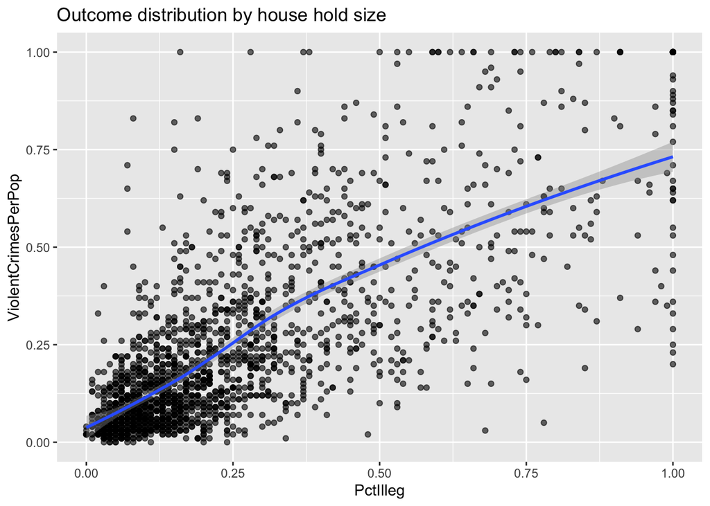

```r
ggplot(df_nomiss, aes(x = PctIlleg, y = ViolentCrimesPerPop)) + geom_point(alpha = 0.6) +
  geom_smooth(method = "loess") +
  labs(title = "Outcome distribution by house hold size")
```

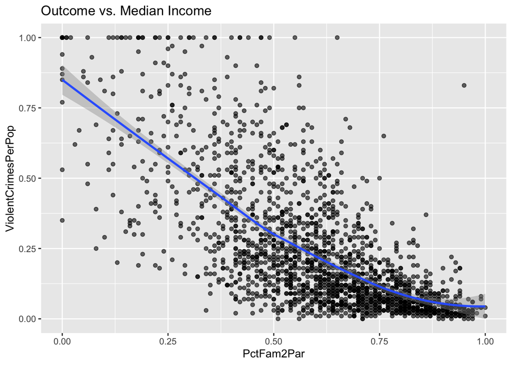

```r
ggplot(df_nomiss, aes(x = PctFam2Par, y = ViolentCrimesPerPop)) + geom_point(alpha = 0.6) +
  geom_smooth(method = "loess") +
  labs(title = "Outcome vs. Median Income")
```

Fit CART with cross-validation to select CP

```r
set.seed(735)

fit.n <- rpart(ViolentCrimesPerPop~.,
               data=df_nomiss,
               method="anova",
               control = list(minbucket = 50,
                              minsplit = 70,
                              cp = 0.0000002,
                              xval = 50))

Fit_table.n <- as.data.frame(fit.n$cptable)
kbl2(Fit_table.n, caption = "50-Fold CV Results for CART")
```

50-Fold CV Results for CART

| CP | nsplit | rel error | xerror | xstd |
| --- | --- | --- | --- | --- |
| 0.4139979 | 0 | 1.0000000 | 1.0011016 | 0.0438467 |
| 0.0706643 | 1 | 0.5860021 | 0.6140449 | 0.0266327 |
| 0.0553229 | 2 | 0.5153378 | 0.5261391 | 0.0238748 |
| 0.0267564 | 3 | 0.4600149 | 0.4776957 | 0.0222939 |
| 0.0195108 | 4 | 0.4332585 | 0.4503099 | 0.0216111 |
| 0.0144275 | 5 | 0.4137477 | 0.4462015 | 0.0220088 |
| 0.0073398 | 6 | 0.3993202 | 0.4369576 | 0.0217285 |
| 0.0068813 | 7 | 0.3919804 | 0.4419272 | 0.0219253 |
| 0.0065252 | 8 | 0.3850991 | 0.4385772 | 0.0218299 |
| 0.0061956 | 9 | 0.3785739 | 0.4354977 | 0.0216258 |
| 0.0051514 | 10 | 0.3723783 | 0.4196026 | 0.0210249 |
| 0.0035724 | 11 | 0.3672269 | 0.4171337 | 0.0210348 |
| 0.0028486 | 12 | 0.3636545 | 0.4188571 | 0.0211918 |
| 0.0027140 | 13 | 0.3608059 | 0.4197577 | 0.0211926 |
| 0.0023495 | 14 | 0.3580919 | 0.4202273 | 0.0213502 |
| 0.0022636 | 15 | 0.3557423 | 0.4191682 | 0.0212857 |
| 0.0020781 | 16 | 0.3534787 | 0.4171072 | 0.0213161 |
| 0.0019848 | 17 | 0.3514006 | 0.4154922 | 0.0212619 |
| 0.0012716 | 18 | 0.3494158 | 0.4142136 | 0.0211067 |
| 0.0011695 | 19 | 0.3481443 | 0.4151531 | 0.0211310 |
| 0.0007356 | 20 | 0.3469748 | 0.4156173 | 0.0211493 |
| 0.0003975 | 21 | 0.3462393 | 0.4158550 | 0.0211847 |
| 0.0003634 | 22 | 0.3458418 | 0.4169206 | 0.0211917 |
| 0.0002941 | 23 | 0.3454783 | 0.4171493 | 0.0211909 |
| 0.0002298 | 24 | 0.3451842 | 0.4167927 | 0.0211820 |
| 0.0001267 | 25 | 0.3449544 | 0.4168745 | 0.0212060 |
| 0.0000832 | 26 | 0.3448277 | 0.4171029 | 0.0212053 |
| 0.0000439 | 27 | 0.3447444 | 0.4169125 | 0.0211754 |
| 0.0000002 | 28 | 0.3447005 | 0.4169337 | 0.0211752 |

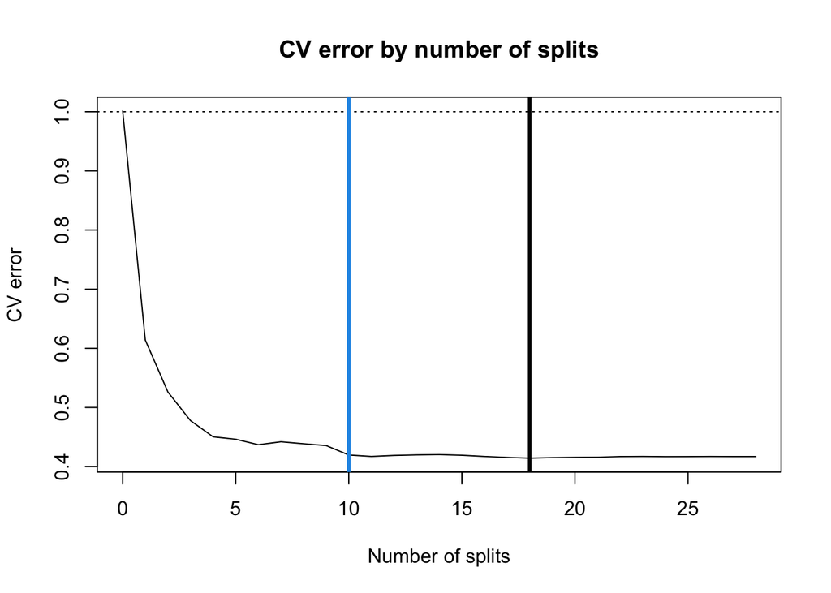

```r
plot(Fit_table.n$nsplit,Fit_table.n$xerror,
     xlab = "Number of splits",ylab="CV error",
     main = "CV error by number of splits",
     type = "l", xlim=c(0,min(c(max(Fit_table.n$nsplit),100))))
abline(h=1,lty=3)


Best_mod <- which.min(Fit_table.n$xerror)
Best_mod_1sd <- which.max(Fit_table.n$xerror < c(Fit_table.n$xerror+Fit_table.n$xstd) [which.min(Fit_table.n$xerror)])
abline(v = Fit_table.n$nsplit[Best_mod] ,lwd=3)
abline(v = Fit_table.n$nsplit[Best_mod_1sd], lwd = 3, col = 4)
```

## 1.1 Final tree

Here, we’ll use the 1-sd criteria to get our final tree:

```r
j <- Best_mod_1sd
kbl2(Fit_table.n[j,])
```

|  | CP | nsplit | rel error | xerror | xstd |
| --- | --- | --- | --- | --- | --- |
| 11 | 0.0051514 | 10 | 0.3723783 | 0.4196026 | 0.0210249 |

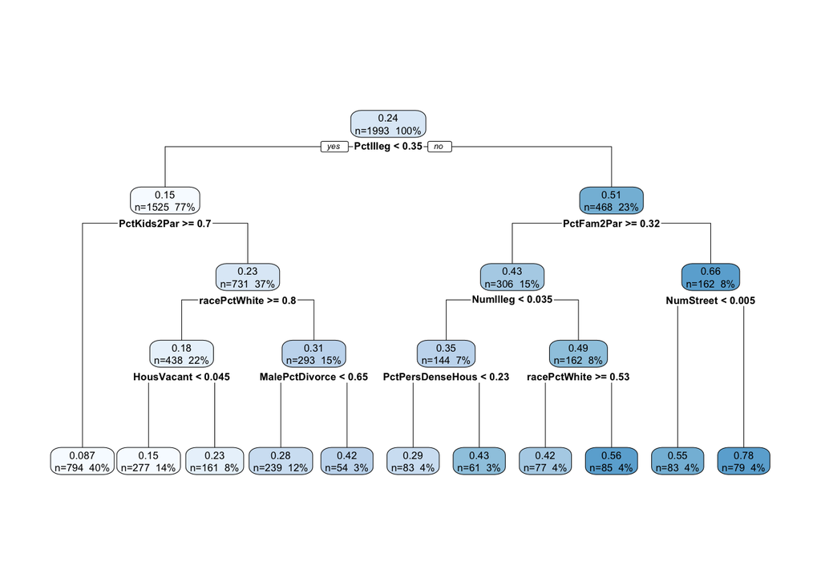

```r
# Get Cp for the best model
cp <- Fit_table.n$CP[j]
# Get the tree for the best model
fit.best <- prune(fit.n,cp=cp)
rpart.plot(fit.best,extra = 101)
```

Some of the variables:

- PctIlleg: percentage of kids born to never married (numeric - decimal)
- PctFam2Par: percentage of families (with kids) that are headed by two parents (numeric - decimal)
- HousVacant: number of vacant households (numeric - decimal)
- MalePctDivorce: percentage of males who are divorced (numeric - decimal)
- PctKids2Par: percentage of kids in family housing with two parents (numeric - decimal)
- NumIlleg: number of kids born to never married (numeric - decimal)
- PctPersDenseHous: percent of persons in dense housing (more than 1 person per room) (numeric - decimal)
- NumStreet: number of homeless people counted in the street (numeric - decimal)

⸻

# 2 Binary Outcome: Pima Indians Diabetes

Next, we classify diabetes status using the Pima Indians Diabetes dataset.

```r
PimaIndiansDiabetes <- read_csv("pima.indians.diabetes3.csv")
bin_df <- na.omit(PimaIndiansDiabetes) |>
  rename(diabetes = class) |>
  select(-classdigit)
head(bin_df)
```

```
# A tibble: 6 × 8
  npregnant glucose diastolic.bp skinfold.thickness   bmi pedigree   age
      <dbl>   <dbl>        <dbl>              <dbl> <dbl>    <dbl> <dbl>
1         6     148           72                 35  33.6    0.627    50
2         1      85           66                 29  26.6    0.351    31
3         1      89           66                 23  28.1    0.167    21
4         0     137           40                 35  43.1    2.29     33
5         3      78           50                 32  31      0.248    26
6         2     197           70                 45  30.5    0.158    53
# ℹ 1 more variable: diabetes <chr>
```

Distribution of outcome by candidate predictors

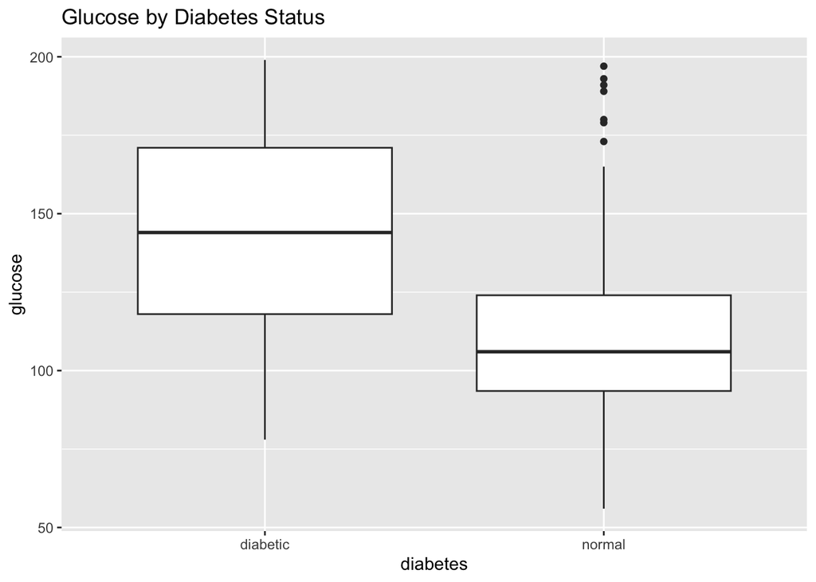

```r
ggplot(bin_df, aes(x = diabetes, y = glucose)) + geom_boxplot() +
  labs(title = "Glucose by Diabetes Status")
```

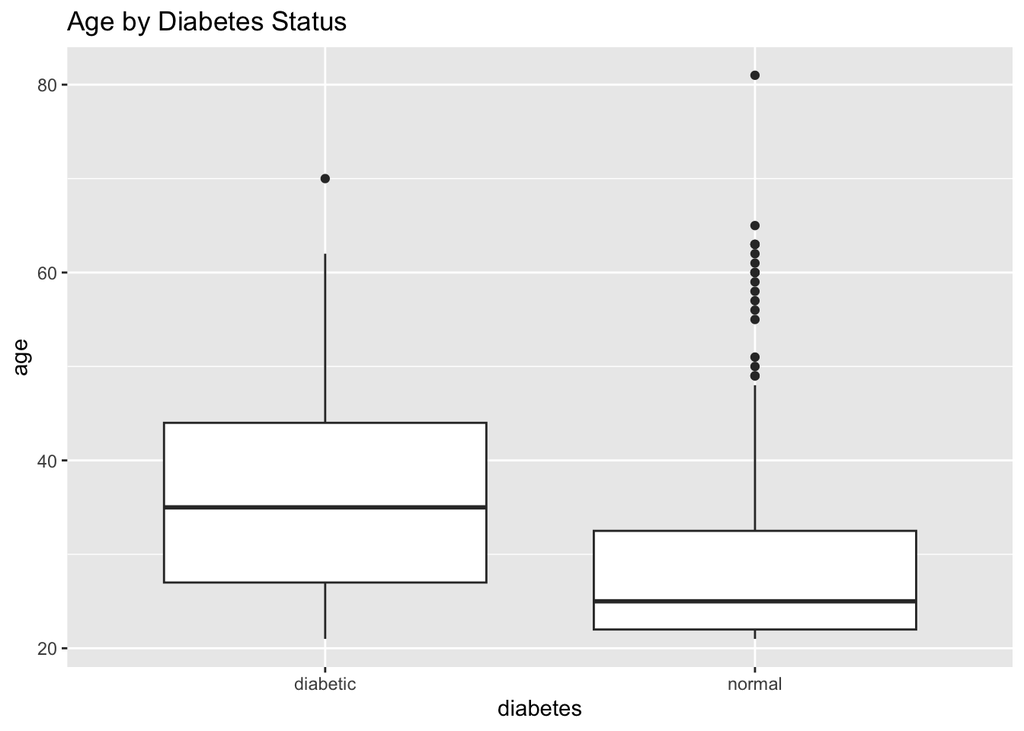

```r
ggplot(bin_df, aes(x = diabetes, y = age)) + geom_boxplot() +
  labs(title = "Age by Diabetes Status")
```

## 2.1 Using `caret` for Model Tuning

So far, we have fit models directly using functions such as `rpart()`. Here we will use the `caret` package.

`caret` provides a common framework for:

1. fitting a model,
2. choosing tuning parameters using cross-validation, and
3. comparing predictive performance across models.

The first step is to tell `caret` **how we want model performance to be evaluated**.

```r
set.seed(735)

train_control <- trainControl(
  method = "cv",
  number = 10,
  classProbs = TRUE,
  summaryFunction = twoClassSummary
)
```

`trainControl()` does **not fit a model**. It defines the resampling procedure that `caret` will use later.

Here we are asking for:

- `method = "cv"`: use cross-validation.
- `number = 10`: use 10 folds.
- `classProbs = TRUE`: calculate predicted probabilities in addition to predicted classes.
- `summaryFunction = twoClassSummary`: calculate ROC AUC, sensitivity, and specificity within the validation folds.

We can now use this same resampling plan to fit different classification models.

## 2.2 Fitting and Tuning CART

```r
cart_class <- train(
  diabetes ~ .,
  data = bin_df,
  method = "rpart",
  trControl = train_control,
  metric = "ROC",
  tuneLength = 10
)

cart_class
```

```
CART

532 samples
  7 predictor
  2 classes: 'diabetic', 'normal'

No pre-processing
Resampling: Cross-Validated (10 fold)
Summary of sample sizes: 480, 478, 480, 480, 478, 478, ...
Resampling results across tuning parameters:

  cp          ROC        Sens       Spec
  0.00000000  0.7823184  0.6169935  0.8111111
  0.02950408  0.7435500  0.5722222  0.8592063
  0.05900816  0.6934015  0.5362745  0.8417460
  0.08851224  0.6992420  0.5532680  0.8333333
  0.11801632  0.6988562  0.5699346  0.8277778
  0.14752040  0.6988562  0.5699346  0.8277778
  0.17702448  0.6988562  0.5699346  0.8277778
  0.20652856  0.6988562  0.5699346  0.8277778
  0.23603264  0.6988562  0.5699346  0.8277778
  0.26553672  0.5982283  0.2954248  0.9010317

ROC was used to select the optimal model using the largest value.
The final value used for the model was cp = 0.
```

The `train()` function coordinates the entire model-fitting and tuning process.

Here:

- `diabetes ~ .` defines the outcome and predictors.
- `method = "rpart"` tells `caret` which type of model to fit.
- `trControl = train_control` tells `caret` to use the 10-fold CV procedure defined above.
- `metric = "ROC"` tells `caret` to choose the tuning parameter that maximizes cross-validated ROC AUC.
- `tuneLength = 10` asks `caret` to consider 10 candidate values of the tuning parameter.

For CART, the tuning parameter is the complexity parameter:

[ cp. ]

Conceptually, `caret` is doing the following:

1. Select candidate values of $cp$.
2. Divide the data into 10 folds.
3. For each value of $cp$:
   - fit CART using 9 folds,
   - predict observations in the remaining fold,
   - calculate ROC AUC,
   - repeat until every fold has served as the validation set.
4. Average the ROC AUC across the 10 folds.
5. Select the value of $cp$ with the largest cross-validated ROC AUC.
6. Fit the final CART model to the full dataset using the selected $cp$.

Thus, `caret` separates two important decisions:

> **What model should we fit?**  
> `method = "rpart"`

and

> **How should we tune and evaluate it?**  
> `trControl = train_control` and `metric = "ROC"`

## 2.3 Looking at the Tuning Results

The cross-validation results for the candidate values of $cp$ are stored in:

```r
cart_class$results
```

```
           cp       ROC      Sens      Spec      ROCSD     SensSD     SpecSD
1  0.00000000 0.7823184 0.6169935 0.8111111 0.05682776 0.08905587 0.10680691
2  0.02950408 0.7435500 0.5722222 0.8592063 0.05363845 0.11905526 0.04819638
3  0.05900816 0.6934015 0.5362745 0.8417460 0.07238665 0.16603859 0.05824337
4  0.08851224 0.6992420 0.5532680 0.8333333 0.07332289 0.17192048 0.05839913
5  0.11801632 0.6988562 0.5699346 0.8277778 0.07310544 0.17813838 0.05810478
6  0.14752040 0.6988562 0.5699346 0.8277778 0.07310544 0.17813838 0.05810478
7  0.17702448 0.6988562 0.5699346 0.8277778 0.07310544 0.17813838 0.05810478
8  0.20652856 0.6988562 0.5699346 0.8277778 0.07310544 0.17813838 0.05810478
9  0.23603264 0.6988562 0.5699346 0.8277778 0.07310544 0.17813838 0.05810478
10 0.26553672 0.5982283 0.2954248 0.9010317 0.10187775 0.29357329 0.10223562
```

We can also plot them:

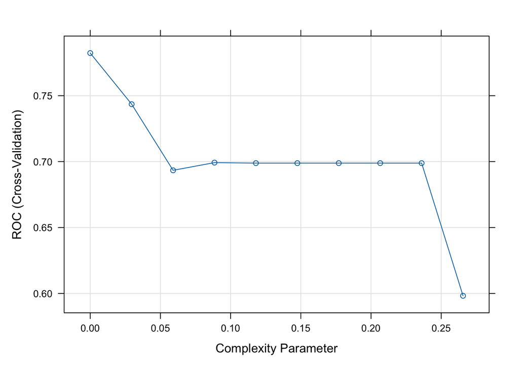

```r
plot(cart_class)
```

The selected tuning parameter is:

```r
cart_class$bestTune
```

```
  cp
1  0
```

## 2.4 Final CART Tree

After selecting $cp$ using cross-validation, `caret` refits CART using the full dataset.

The resulting `rpart` model is stored in:

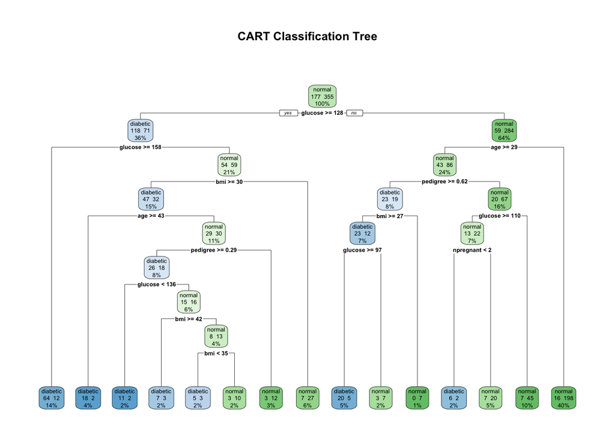

```r
best_tree_class <- cart_class$finalModel

rpart.plot(
  best_tree_class,
  main = "CART Classification Tree",
  extra = 101
)
```

The important distinction is:

- `cart_class` contains the **entire caret analysis**, including the CV results and tuning information.
- `cart_class$finalModel` contains the **final fitted CART model** selected by that procedure. ⸻

# 3 Compare CART vs Naive Bayes for Pima Indians Diabetes

## 3.1 Using the Same Framework for Naive Bayes

One advantage of `caret` is that the same general workflow can be used for many different machine learning methods.

For CART we used:

```r
method = "rpart"
```

For Naive Bayes we simply change the modeling method:

```r
nb_grid <- expand.grid(
  usekernel = c(TRUE, FALSE),
  laplace   = c(0, 1, 2),
  adjust    = c(0.5, 1, 1.5, 2)
) |>
  # adjust only matters when usekernel = TRUE
  filter(!(!usekernel & adjust > 0.5))

set.seed(735)

nb_model <- train(
  diabetes ~ .,
  data = bin_df,
  method = "naive_bayes",
  trControl = train_control,
  metric = "ROC",
  tuneGrid = nb_grid
)
```

Notice that we use the **same `train_control` object**.

Thus, CART and Naive Bayes are evaluated using the same:

- 10-fold cross-validation strategy,
- prediction metric (ROC AUC), and
- general model-selection framework.

What changes is the statistical model being fit.

```r
nb_model$results|> kbl2(digits = 3)
```

|  | usekernel | laplace | adjust | ROC | Sens | Spec | ROCSD | SensSD | SpecSD |
| --- | --- | --- | --- | --- | --- | --- | --- | --- | --- |
| 1 | FALSE | 0 | 0.5 | 0.835 | 0.651 | 0.811 | 0.034 | 0.105 | 0.070 |
| 4 | TRUE | 0 | 0.5 | 0.823 | 0.628 | 0.842 | 0.061 | 0.124 | 0.060 |
| 5 | TRUE | 0 | 1.0 | 0.840 | 0.673 | 0.831 | 0.047 | 0.101 | 0.061 |
| 6 | TRUE | 0 | 1.5 | 0.843 | 0.628 | 0.845 | 0.042 | 0.105 | 0.054 |
| 7 | TRUE | 0 | 2.0 | 0.843 | 0.605 | 0.854 | 0.039 | 0.102 | 0.061 |
| 2 | FALSE | 1 | 0.5 | 0.835 | 0.651 | 0.811 | 0.034 | 0.105 | 0.070 |
| 8 | TRUE | 1 | 0.5 | 0.823 | 0.628 | 0.842 | 0.061 | 0.124 | 0.060 |
| 9 | TRUE | 1 | 1.0 | 0.840 | 0.673 | 0.831 | 0.047 | 0.101 | 0.061 |
| 10 | TRUE | 1 | 1.5 | 0.843 | 0.628 | 0.845 | 0.042 | 0.105 | 0.054 |
| 11 | TRUE | 1 | 2.0 | 0.843 | 0.605 | 0.854 | 0.039 | 0.102 | 0.061 |
| 3 | FALSE | 2 | 0.5 | 0.835 | 0.651 | 0.811 | 0.034 | 0.105 | 0.070 |
| 12 | TRUE | 2 | 0.5 | 0.823 | 0.628 | 0.842 | 0.061 | 0.124 | 0.060 |
| 13 | TRUE | 2 | 1.0 | 0.840 | 0.673 | 0.831 | 0.047 | 0.101 | 0.061 |
| 14 | TRUE | 2 | 1.5 | 0.843 | 0.628 | 0.845 | 0.042 | 0.105 | 0.054 |
| 15 | TRUE | 2 | 2.0 | 0.843 | 0.605 | 0.854 | 0.039 | 0.102 | 0.061 |

```r
nb_model$bestTune |> kbl2()
```

|  | laplace | usekernel | adjust |
| --- | --- | --- | --- |
| 6 | 0 | TRUE | 1.5 |

## 3.2 Compare ROC AUC

```r
results <- resamples(list(CART = cart_class, NB = nb_model))
```

**Code Explanation**

• `resamples()` is a caret function that takes multiple fitted caret models (here cart_class and nb_model) and extracts the resampling results (cross-validation scores).

• `list(CART = cart_class, NB = nb_model)` names each model so they can be compared side by side.

```r
summary(results)
```

```
Call:
summary.resamples(object = results)

Models: CART, NB
Number of resamples: 10

ROC
          Min.   1st Qu.    Median      Mean   3rd Qu.      Max. NA's
CART 0.7191358 0.7319098 0.7738095 0.7823184 0.8243143 0.8630252    0
NB   0.7697479 0.8163580 0.8365442 0.8433380 0.8764505 0.9000000    0

Sens
          Min.   1st Qu.   Median      Mean   3rd Qu.      Max. NA's
CART 0.5000000 0.5277778 0.629085 0.6169935 0.6960784 0.7222222    0
NB   0.4444444 0.5694444 0.629085 0.6281046 0.7058824 0.7777778    0

Spec
          Min.   1st Qu.    Median      Mean   3rd Qu.      Max. NA's
CART 0.5428571 0.8285714 0.8333333 0.8111111 0.8611111 0.9142857    0
NB   0.7777778 0.8113095 0.8333333 0.8453968 0.8601190 0.9714286    0
```

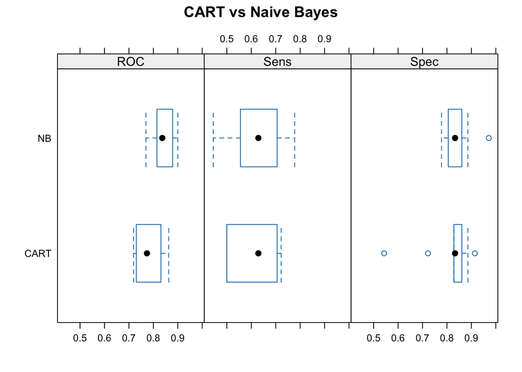

```r
bwplot(results, main = "CART vs Naive Bayes")
```

⸻

Key Takeaways

• CART flexibly partitions the predictor space for continuous or binary outcomes.

• Cross-validation is essential for tuning tree complexity (cp).

• CART trees are interpretable but may not always perform as well as other classifiers.

• Naive Bayes provides a useful baseline for classification problems and often complements CART in comparison.